# Analysis of Single-Cell RNA-seq - Session 4

Emily V Chambers

Last modified: 10 Jan 2023

# Introduction

To re-cap - we have obtained our raw counts matrices from GEO (or cellranger). We have performed QC and subset the data according to the QC plots we generated. We have normalised the data, selected the most variable features and scaled the values - regressing out unwanted sources of variation.

In the next part of the course we are going to explore the genes that show the most differences in their expression between clusters. The top genes showing the biggest change in their expression comapred to the other clusters are often called *marker genes*. We can then use these marker genes to assign an *identity class* to our clusters of interest.

## Learning Objectives

- Find differentially expressed genes using `FindMarkers()` and `FindAllMarkers()`.
- Use the bioconductor human annotation package `org.Hs.eg.db` to add some more further annotation to our marker genes.
- Assign cluster identity using canonical marker genes
- Carry out a simple pathway analysis

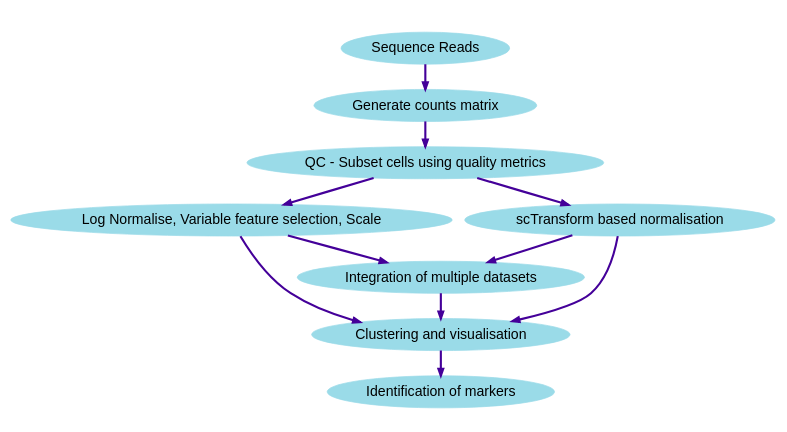

Firstly, we will load up the packages we have been using so far for this part of the course.

```r
library(Seurat, quietly = T)
library(tidyverse, quietly = T)
```

And then we can load up the R objects we have used in the previous sessions.

```r
seurat <- readRDS("Robjects/seurat_integrated.RDS")
```

We can simply run the name of the Seurat object (in our case `seurat`) to give us a summary of what the object contains and what calculations have been performed on it.

```r
seurat
```

```
An object of class Seurat
52114 features across 3322 samples within 3 assays
Active assay: integrated (3000 features, 3000 variable features)
 2 other assays present: RNA, SCT
 3 dimensional reductions calculated: pca, tsne, umap
```

We can recap our clusters by taking a look at the `DimPlot`

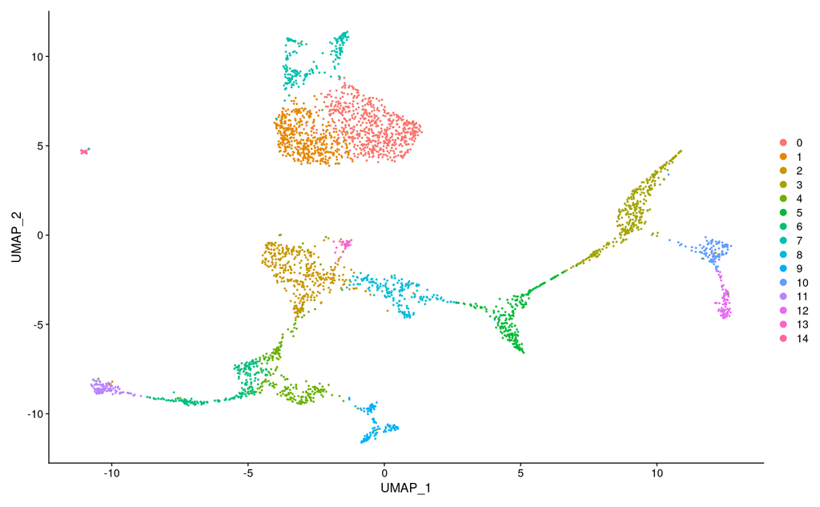

```r
DimPlot(seurat, reduction = "umap")
```

# Find differentially expressed genes

Our next objective is to start assigning some *biological meaning* to our data. We have some nice clusters but no clue yet what cell groups out clusters contain.

In Seurat we can find the top differentially expressed genes, or markers, within each cluster. The function `FindMarkers()` handles most of the differential expression testing within the Seurat package and finds marker genes within a particular cluster. As a default, Seurat performs differential expression based on the non-parameteric Wilcoxon rank sum test but other methods are available within the function.

To start with we can find all the differentially expressed genes in cluster 3 compared to every other cluster. The min.pct argument requires a gene to be detected at a minimum percentage of all the cells.

Since we have performed integration in a previous step, we set the default assay back to ‘RNA’ to ensure we are using the raw counts, rather than counts transformed by integration, for our differential analysis.

```r
# We make sure the default assay is set back to "RNA" to use the original counts for DE analysis.
DefaultAssay(seurat) <- "RNA"
```

[output not shown]

A little bit of table manipulation in `dplyr` makes the markers easier to view…

[output not shown]

To check our DE findings, we can visualize expression of a particular gene of interest across all clusters using the `VlnPlot()` function. This shows the expression levels of a gene (or genes) of interest within the cells across all clusters.

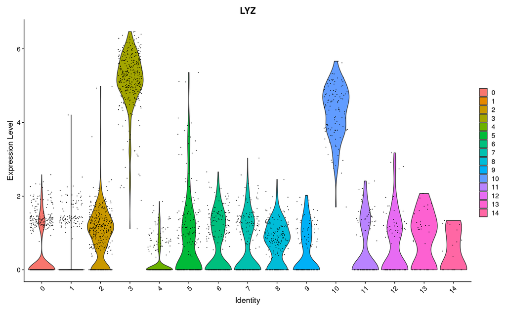

```r
VlnPlot(seurat, features = "LYZ")
```

We can also check which cells express our gene of interest on the UMAP image using `FeaturePlot`

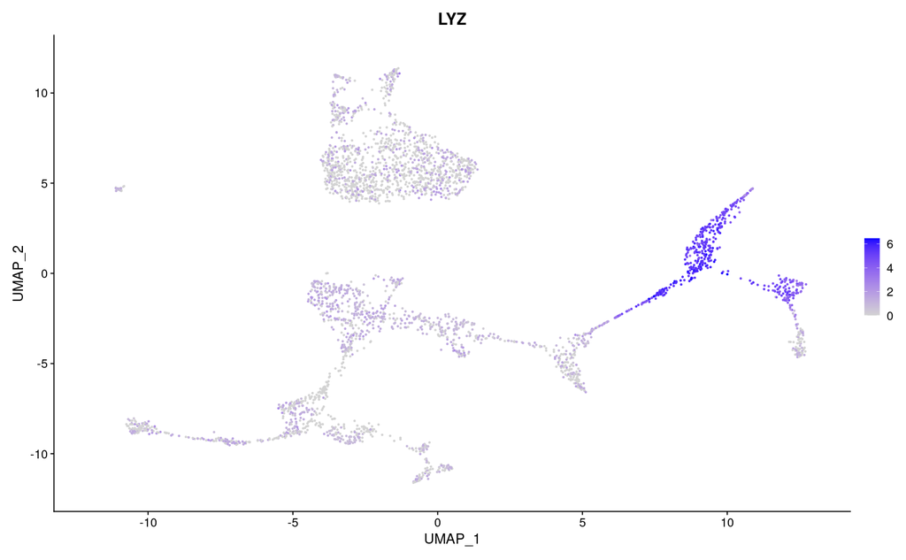

```r
FeaturePlot(seurat, features = "LYZ")
```

Perhaps we are most interested in the differentially expressed genes between clusters 1 and 3

```r
cluster1.markers <- FindMarkers(seurat,
                                ident.1 = 1,
                                ident.2 = 3,
                                min.pct = 0.25)
```

[output not shown]

[output cut: 45 more lines]

[output not shown]

```r
cluster1.markers %>% head()
```

|  | p_val | avg_log2FC | pct.1 | pct.2 | p_val_adj |
| --- | --- | --- | --- | --- | --- |
| TYROBP | 3.653748e-145 | -1.884839 | 0.050 | 0.962 | 1.231094e-140 |
| CST3 | 1.293747e-143 | -1.746176 | 0.093 | 0.979 | 4.359152e-139 |
| LGALS1 | 8.060509e-143 | -1.881390 | 0.132 | 0.988 | 2.715908e-138 |
| LYZ | 9.229257e-142 | -2.188808 | 0.225 | 1.000 | 3.109706e-137 |
| RP11-1143G9.4 | 3.745587e-139 | -2.000822 | 0.225 | 0.997 | 1.262038e-134 |
| FCER1G | 2.828509e-138 | -1.644270 | 0.048 | 0.941 | 9.530378e-134 |

… or the DE genes between clusters 1 in comparison to 3 and 4?

```r
cluster1.markers <- FindMarkers(seurat, ident.1 = 1,
                                ident.2 = c(3,4), # we can group clusters together!
                                min.pct = 0.25)
```

[output not shown]

[output cut: 45 more lines]

[output not shown]

```r
cluster1.markers %>% head()
```

|  | p_val | avg_log2FC | pct.1 | pct.2 | p_val_adj |
| --- | --- | --- | --- | --- | --- |
| RPS27 | 4.872900e-163 | 0.2574239 | 1.000 | 0.998 | 1.641875e-158 |
| MALAT1 | 5.505388e-144 | 0.3240256 | 1.000 | 1.000 | 1.854985e-139 |
| HLA-DRA | 1.983664e-143 | -1.3723756 | 0.219 | 0.946 | 6.683758e-139 |
| CD74 | 1.581884e-136 | -1.2171094 | 0.320 | 0.963 | 5.330001e-132 |
| GAPDH | 1.327937e-128 | -0.9565244 | 0.561 | 0.961 | 4.474351e-124 |
| ACTB | 1.642723e-125 | -0.4799432 | 0.872 | 0.997 | 5.534990e-121 |

Usually, we are wanting to find the most differentially expressed genes in each cluster across the whole dataset. For this we use `FindAllMarkers`. This time we will only report the positively expressed markers with a minimum log fold change of 0.25.

[output not shown]

[output cut: 990 more lines]

Again, a bit of manipulation in `dplyr` enables us to get the top 5 DE genes in each cluster.

```r
markers %>%
  select(gene, cluster, avg_log2FC, p_val, p_val_adj) %>%
    group_by(cluster) %>%
    slice_max(n = 5, order_by = avg_log2FC)
```

| gene | cluster | avg_log2FC | p_val | p_val_adj |
| --- | --- | --- | --- | --- |
| CD8B | 0 | 2.533903 | 4.804896e-120 | 1.441469e-116 |
| CD3D | 0 | 1.899452 | 2.010169e-91 | 6.030506e-88 |
| RP11-291B21.2 | 0 | 1.795471 | 5.563670e-49 | 1.669101e-45 |
| IL32 | 0 | 1.774140 | 5.733803e-73 | 1.720141e-69 |
| CD7 | 0 | 1.676768 | 1.094416e-62 | 3.283248e-59 |
| LTB | 1 | 1.735509 | 2.031449e-69 | 6.094346e-66 |
| IL7R | 1 | 1.685498 | 1.192871e-81 | 3.578614e-78 |
| RPS27 | 1 | 1.549206 | 3.371166e-139 | 1.011350e-135 |
| FYB | 1 | 1.496811 | 2.195748e-59 | 6.587245e-56 |
| TRBC1 | 1 | 1.457637 | 3.144046e-35 | 9.432139e-32 |

[output cut: 65 more lines]

## Exercise

- Use `FindMarkers` to find the differentially expressed genes in clusters 1 & 2 vs 8
- Can you use `dplyr` to select columns of interest and order them by log fold change?
- Use one of the visualisation tools to look at the expression of one of the top marker genes

```r
#Put exercise work in here :-)
```

# Annotating marker genes

We may want to share our findings with collaborators or perform further bioinformatic analysis on our DE genes in clusters of interest. In this dataset, the gene level information is given as a gene name. Whilst this is useful we may want to embellish these results with some gene description information or some other gene IDs (eg Ensembl, Entrez).

The `org.Hs.eg.db` database is a genome wide annotation package for human that has many different gene mappings based on Entrez Gene identifiers. These are up to data databases of gene annotation that can be installed like any other bioconductor package

In our case we are going to use the gene symbols (rownames in our Seurat object) to extract the gene description and entrez ID from the database. In order to see what we can extract from the database we can run the `columns` function on the annotation database.

```r
columns(org.Hs.eg.db) # We can use this command to see which data can be pulled from the database
```

```
 [1] "ACCNUM"       "ALIAS"        "ENSEMBL"      "ENSEMBLPROT"  "ENSEMBLTRANS" "ENTREZID"     "ENZYME"
 [8] "EVIDENCE"     "EVIDENCEALL"  "GENENAME"     "GENETYPE"     "GO"           "GOALL"        "IPI"
[15] "MAP"          "OMIM"         "ONTOLOGY"     "ONTOLOGYALL"  "PATH"         "PFAM"         "PMID"
[22] "PROSITE"      "REFSEQ"       "SYMBOL"       "UCSCKG"       "UNIPROT"
```

We are going to filter the database by a key or set of keys in order to extract the information we want. Valid names for the key can be retrieved with the `keytypes` function.

```r
keytypes(org.Hs.eg.db)
```

```
 [1] "ACCNUM"       "ALIAS"        "ENSEMBL"      "ENSEMBLPROT"  "ENSEMBLTRANS" "ENTREZID"     "ENZYME"
 [8] "EVIDENCE"     "EVIDENCEALL"  "GENENAME"     "GENETYPE"     "GO"           "GOALL"        "IPI"
[15] "MAP"          "OMIM"         "ONTOLOGY"     "ONTOLOGYALL"  "PATH"         "PFAM"         "PMID"
[22] "PROSITE"      "REFSEQ"       "SYMBOL"       "UCSCKG"       "UNIPROT"
```

We are going to use the keytype ‘SYMBOL’ which designates the gene names that we have in our rownames of the seurat object.

Unfortunately, the authors of `dplyr` and `AnnotationDbi` have both decided to use the name `select` in their packages. To avoid confusion and problems from packages attempting to use the wrong tool, the following code is sometimes used:-

AnnotationDbi::select which tells us to use the ‘select’ function from the AnnotationDBI package.

```r
anno <- AnnotationDbi::select(org.Hs.eg.db,
                              keys=rownames(seurat),
                              columns=c("SYMBOL","GENENAME", "ENTREZID"),  # info we want to extract
                              keytype = "SYMBOL") # information we have

# Check it worked!
head(anno)
```

|  | SYMBOL | GENENAME | ENTREZID |
| --- | --- | --- | --- |
| 1 | RP11-34P13.3 | NA | NA |
| 2 | FAM138A | family with sequence similarity 138 member A | 645520 |
| 3 | OR4F5 | olfactory receptor family 4 subfamily F member 5 | 79501 |
| 4 | RP11-34P13.7 | NA | NA |
| 5 | RP11-34P13.8 | NA | NA |
| 6 | RP11-34P13.14 | NA | NA |

Now we can combine our annotation table to our marker genes using `dplyr` and `left_join`

```r
anno_markers <- markers %>%
  dplyr::select(gene, cluster, avg_log2FC, p_val, p_val_adj) %>%
  left_join(anno, by = c("gene" = "SYMBOL"))

anno_markers %>% head()
```

|  | gene | cluster | avg_log2FC | p_val | p_val_adj | GENENAME | ENTREZID |
| --- | --- | --- | --- | --- | --- | --- | --- |
| 1 | RPL21 | 0 | 1.497486 | 1.069294e-161 | 3.207883e-158 | ribosomal protein L21 | 6144 |
| 2 | CD8B | 0 | 2.533903 | 4.804896e-120 | 1.441469e-116 | CD8b molecule | 926 |
| 3 | RPS19 | 0 | 1.067480 | 1.943847e-114 | 5.831540e-111 | ribosomal protein S19 | 6223 |
| 4 | RPS27 | 0 | 1.199446 | 2.177953e-96 | 6.533858e-93 | ribosomal protein S27 | 6232 |
| 5 | CD3D | 0 | 1.899452 | 2.010169e-91 | 6.030506e-88 | CD3 delta subunit of T-cell receptor complex | 915 |
| 6 | RPS12 | 0 | 1.058389 | 5.569686e-91 | 1.670906e-87 | ribosomal protein S12 | 6206 |

```r
NA
```

At this point we might want to save our result into a nicely formatted file where we can look up our clusters, top DE genes and their gene descriptions.

```r
anno_markers %>% write_csv("Annotated.results.csv")
```

# Assigning cluster identity

If you recall, our dataset is from the following paper:-

> Caron M, St-Onge P, Sontag T, Wang YC et al. Single-cell analysis of childhood leukemia reveals a link between developmental states and ribosomal protein expression as a source of intra-individual heterogeneity. Sci Rep 2020 May15;10(1):8079

This paper uses the following *canonical marker genes* to assign cell cluster identity. This starts to give some *biological meaning* to our results.

These genes are known to be expressed in a particular cell type.

| Gene | Cell type |
| --- | --- |
| CD79A | B Cells |
| CD34 | CD34+, |
| MS4A1 | CD20+ B cells, |
| MZB1 | BCMA, |
| CST3 | Monocytes, |
| SPN Im | mature hematopoietic, |
| HBA1 | erythrocytes, |
| CD3D | T cells, |
| NKG7 | NK cells |

We can assign these marker genes as a variable

```r
cell_markers <- c("CD79A","CD34", "MS4A1", "MZB1","CST3" ,"SPN", "KIT", "HBA1", "CD3D", "NKG7")
```

Dot plots allow us to examine particular features or genes of interest across all clusters. Creating a dotplot of the cell type markers lets us assign identity based on their expression.

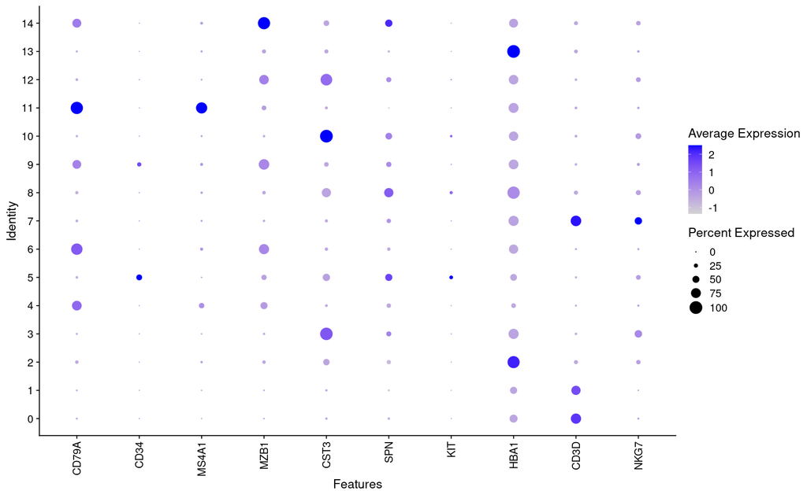

```r
DotPlot(seurat, features = cell_markers) + theme(axis.text.x = element_text(angle = 90, vjust = 0.5, hjust=1))
```

We can then manually create new identities for each cluster as follows.

```r
new.cluster.ids <- c("T Cells", #0
                     "T Cells", #1
                     "Erythrocytes", #2
                     "Monocytes",  #3
                     "B Cells", #4
                     "CD34+", #5
                     "B Cells", #6
                     "NK Cells", #7
                     "Immature hema#8topoietic",
                     "CD79A B cells",#9
                     "Monocytes", #10
                     "CD20+ B cells", #11
                     "BCMA", #12
                     "Erythrocytes", #13
                     "BCMA") #14
names(new.cluster.ids) <- levels(seurat)
new.cluster.ids
```

```
                         0                          1                          2                          3
                 "T Cells"                  "T Cells"             "Erythrocytes"                "Monocytes"
                         4                          5                          6                          7
                 "B Cells"                    "CD34+"                  "B Cells"                 "NK Cells"
                         8                          9                         10                         11
"Immature hema#8topoietic"            "CD79A B cells"                "Monocytes"            "CD20+ B cells"
                        12                         13                         14
                    "BCMA"             "Erythrocytes"                     "BCMA"
```

```r
seurat_named <- RenameIdents(seurat, new.cluster.ids)
```

[figure not shown]

```r
DimPlot(seurat_named, reduction = "umap", label = TRUE, pt.size = 0.5) + NoLegend()
```

We can check our result to the UMAP plot produced from the full dataset within the paper - not too bad! Considering we have used a subset and not followed their exact method.

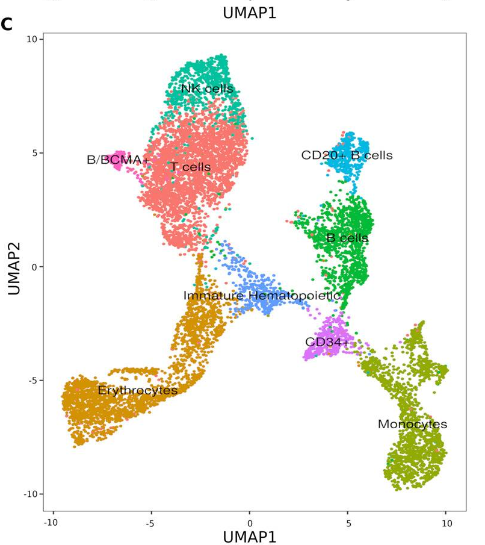

# GO term and pathway enrichment

Sometimes we want to carry out a *Gene Enrichment Analysis* on a list of genes of interest. This enables us to find *functional terms* that are statistically over represented within a group of genes compared to a background list. `clusterProfiler` is an R package that provides statistical tests for expression analysis of terms such as GO (Gene Ontology), within gene lists that have shown statistically significant differences.

When using this tool we need to have two inputs: a list of genes that show significant differentiation in expression and a list of background genes. Hypergeometric tests are used for statistical enrichment analysis test.

We can check for GO terms measuring BP (biological process), CC (cell component) and MF (molecular function).

[output not shown]

`clusterProfiler` also has functionality to plot pathway diagrams for us.

```
$dag
A graphNEL graph with directed edges
Number of Nodes = 90
Number of Edges = 171

$complete.dag
[1] "A graph with 90 nodes."
```

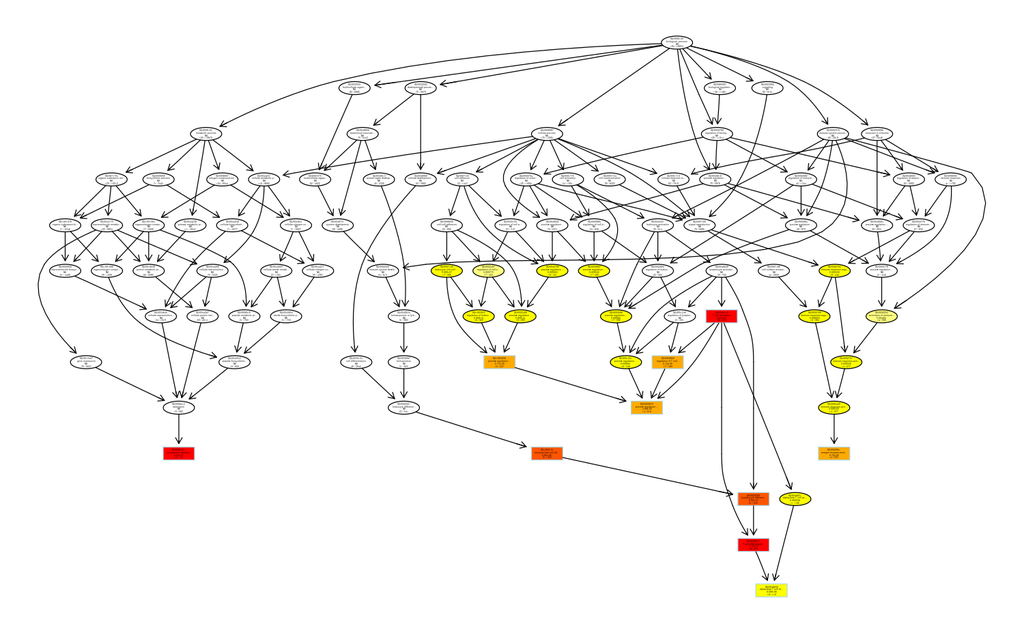

```r
plotGOgraph(eGO)
```